# Class Work

Nicholas Jacob

2025-02-07

# Data

## Loading Data

```r
df <- read.csv("StudentSurveys.csv")

head(df)
```

```
##        Year Gender Smoke   Award HigherSAT Exercise TV Height Weight Siblings
## 1    Senior      M    No Olympic      Math       10  1     71    180        4
## 2 Sophomore      F   Yes Academy      Math        4  7     66    120        2
## 3 FirstYear      M    No   Nobel      Math       14  5     72    208        2
## 4    Junior      M    No   Nobel      Math        3  1     63    110        1
## 5 Sophomore      F    No   Nobel    Verbal        3  3     65    150        1
## 6 Sophomore      F    No   Nobel    Verbal        5  4     65    114        2
##   BirthOrder VerbalSAT MathSAT  SAT  GPA Pulse Piercings
## 1          4       540     670 1210 3.13    54         0
## 2          2       520     630 1150 2.50    66         3
## 3          1       550     560 1110 2.55   130         0
## 4          1       490     630 1120 3.10    78         0
## 5          1       720     450 1170 2.70    40         6
## 6          2       600     550 1150 3.20    80         4
```

## Wrangling the Data with `dplyr`

You should note that I added dplyr to the library above. Following code gives me a frequency table.

```r
df |>
  count(Year)
```

```
##        Year   n
## 1             2
## 2 FirstYear  94
## 3    Junior  35
## 4    Senior  36
## 5 Sophomore 195
```

We should note that there are `na`s in the data and the order is alphabetical. We can change the datatype to fix this.

```r
df %>%
  mutate(Year = factor(Year,levels  = c("FirstYear","Sophomore", "Junior", "Senior")))%>%
  count(Year)
```

```
##        Year   n
## 1 FirstYear  94
## 2 Sophomore 195
## 3    Junior  35
## 4    Senior  36
## 5      <NA>   2
```

What if I want to look at GPA by grade level.

```r
df %>%
  group_by(Year)%>%
  summarise(avg = mean(GPA, na.rm = TRUE), std = sd(GPA, na.rm = TRUE))
```

```
## # A tibble: 5 × 3
##   Year           avg    std
##   <chr>        <dbl>  <dbl>
## 1 ""          NaN    NA
## 2 "FirstYear"   3.08  0.466
## 3 "Junior"      3.24  0.394
## 4 "Senior"      3.17  0.375
## 5 "Sophomore"   3.18  0.369
```

```r
df |>
  filter(Year == "Junior")|>
 # mutate(HigherSAT = if_else(VerbalSAT >= MathSAT, "Verbal", "Math"))|> #if the actual wasn't there
  count(HigherSAT)
```

```
##   HigherSAT  n
## 1            2
## 2      Math 19
## 3    Verbal 14
```

## Wrangling Data With Base

```r
table(df[df$Year=="Junior","HigherSAT"])
```

```
##
##          Math Verbal
##      2     19     14
```

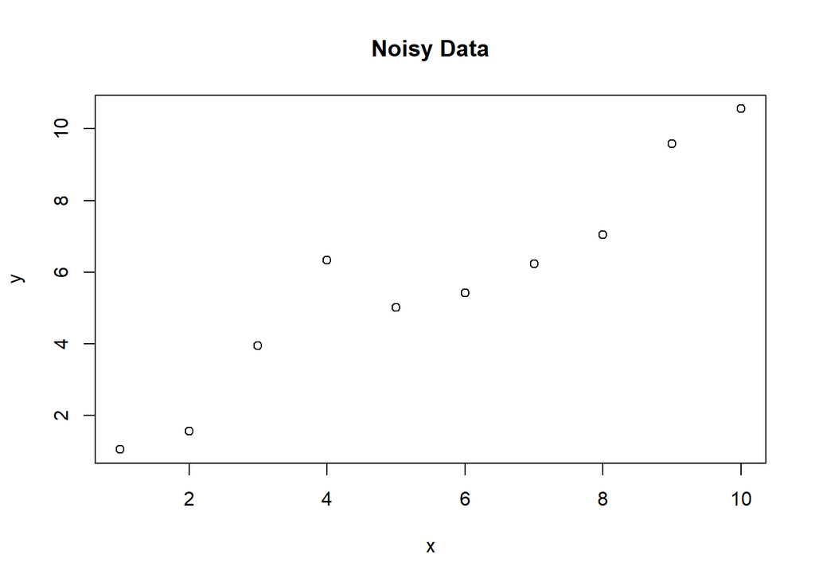

```r
x = c(1:10)
y = x + rnorm(10)

plot(x,y, main = "Noisy Data")
```

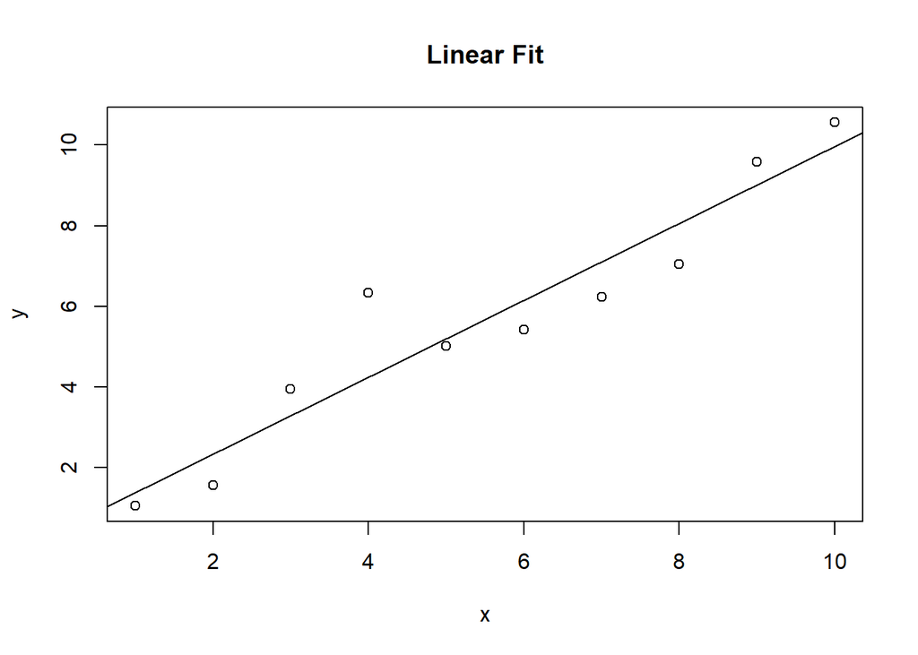

```r
fit <- lm(y~x)

plot(x,y, main = "Linear Fit")
abline(fit)
```

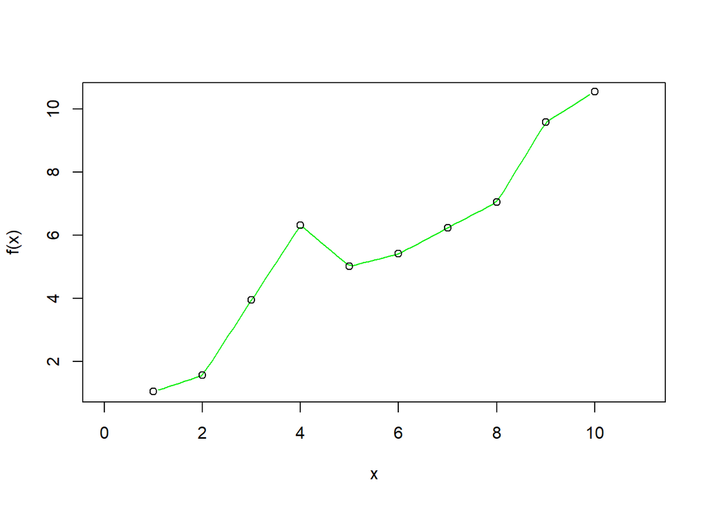

```r
f <- approxfun(x, y)
curve(f(x), 0, 11, col = "green2")
points(x, y)
```

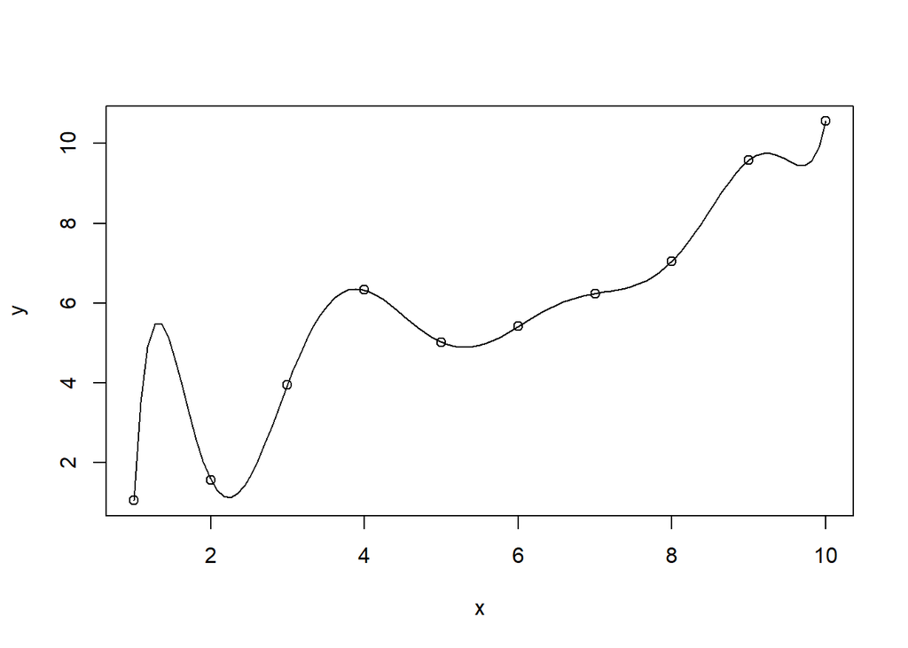

```r
lagrange <- function(x0, y0) {
  f <- function (x) {
    sum(y0 * sapply(seq_along(x0), \(j) {
      prod(x - x0[-j])/prod(x0[j] - x0[-j])
    }))
  }
  Vectorize(f, "x")
} #https://stackoverflow.com/questions/73994021/lagrange-interpolation-formula-in-r-programming

f <- lagrange(x,y)
plot(x,y)
curve(f, from = 1, to = 10, add = TRUE)
```

## Accuracy or Precision

How would you model? I would have two random variables describing my desired outcome. One I would think of as the initial placement and the other the noise. I would tune both based on how high I allowed the accuracy and precision to be respectively.

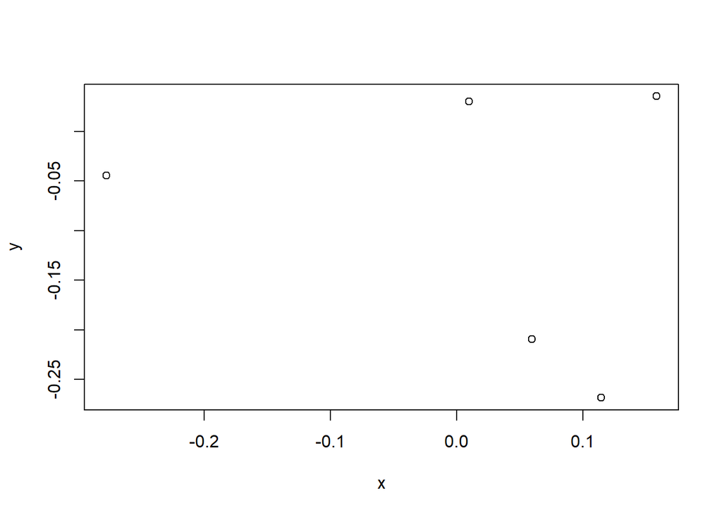

```r
n <- 5
acc <- .1
prec <- .1

x<- rnorm(5,mean = 0, sd = acc)+rnorm(5,mean = 0, sd = prec)
y<- rnorm(5,mean = 0, sd = acc)+rnorm(5,mean = 0, sd = prec)

plot(x,y)#This doesn't work as well as I hoped...
```

## Data Types

```r
x <- c(1:100)

evens <- x%%2==0

x[evens]
```

```
##  [1]   2   4   6   8  10  12  14  16  18  20  22  24  26  28  30  32  34  36  38
## [20]  40  42  44  46  48  50  52  54  56  58  60  62  64  66  68  70  72  74  76
## [39]  78  80  82  84  86  88  90  92  94  96  98 100
```

Look at the student set, explore the different picks.

```r
disney <- read.csv("disney.csv")



weekdays(mdy(disney$Release.date..datetime.))[1]
```

```
## [1] "Wednesday"
```

## Statistics

[output not shown]

Making this table look at bit nicer as it displays:

```r
df |>
  group_by(Year) |>
  summarise("Aritmetic Mean" = mean(GPA, na.rm = TRUE),
            "Geometric Mean" = exp(mean(log(GPA), na.rm = TRUE)),
            "Standard Deviation" = sd(GPA, na.rm = TRUE),
            "InterQuartile Range" = IQR(GPA, na.rm = TRUE)
            ) |>
  kable()
```

| Year | Aritmetic Mean | Geometric Mean | Standard Deviation | InterQuartile Range |
| --- | --- | --- | --- | --- |
|  | NaN | NaN | NA | NA |
| FirstYear | 3.077654 | 3.041365 | 0.4664528 | 0.600 |
| Junior | 3.235143 | 3.210625 | 0.3943824 | 0.515 |
| Senior | 3.171667 | 3.148689 | 0.3754274 | 0.400 |
| Sophomore | 3.175078 | 3.152564 | 0.3690996 | 0.500 |

```r
t.test(df[df$Year == "FirstYear","GPA"],df[df$Year == "Senior","GPA"])
```

```
##
##  Welch Two Sample t-test
##
## data:  df[df$Year == "FirstYear", "GPA"] and df[df$Year == "Senior", "GPA"]
## t = -1.1571, df = 82.509, p-value = 0.2506
## alternative hypothesis: true difference in means is not equal to 0
## 95 percent confidence interval:
##  -0.25562644  0.06760174
## sample estimates:
## mean of x mean of y
##  3.077654  3.171667
```

## Graphing

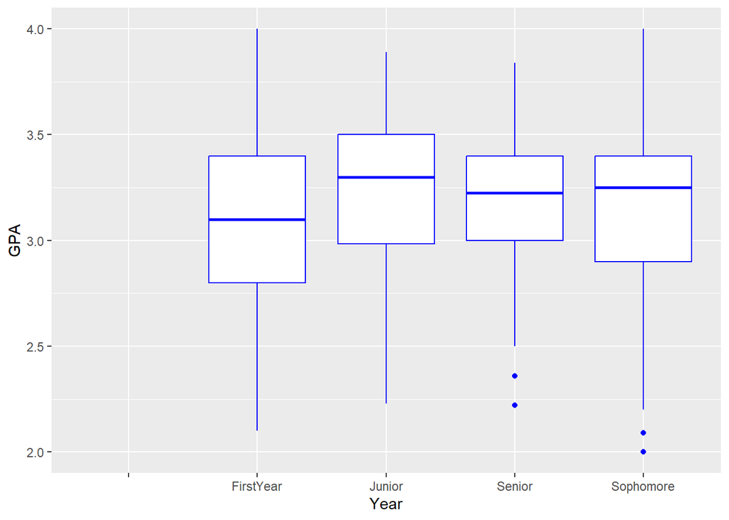

```r
ggplot(data = df, aes(x = Year, y = GPA)) +
  geom_boxplot(color = 'blue')
```

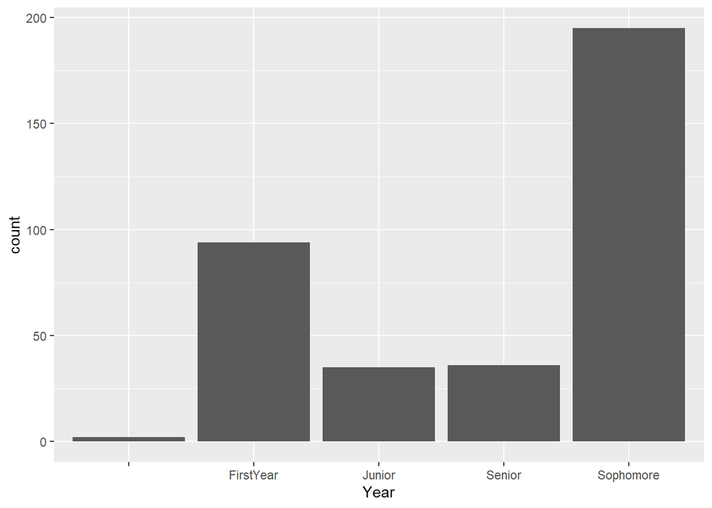

```r
ggplot(data = df, aes(x = Year))+
  geom_bar()
```

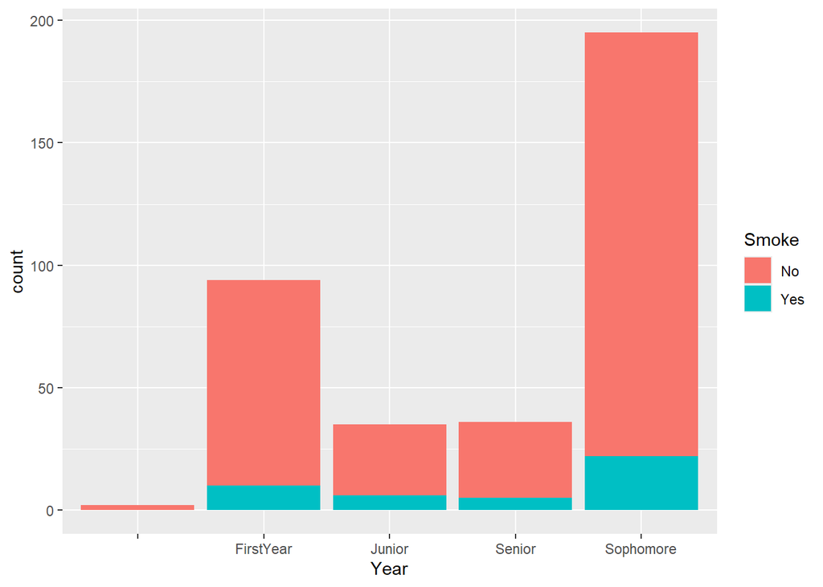

```r
ggplot(df, aes(x = Year, fill = Smoke)) +
  geom_bar()
```

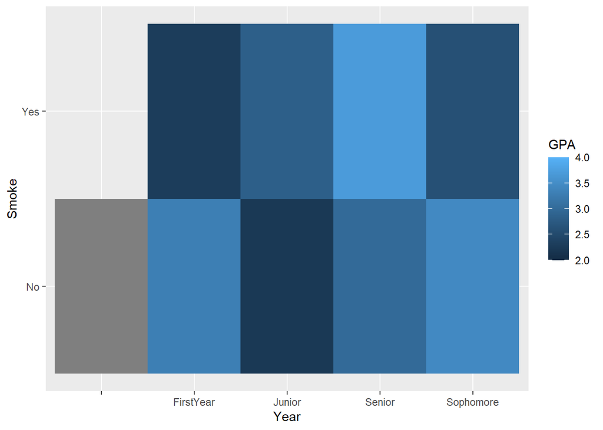

```r
ggplot(df, aes(x = Year, y = Smoke, fill = GPA)) +
  geom_tile()
```

What if I really wanted those values? It was much harder…

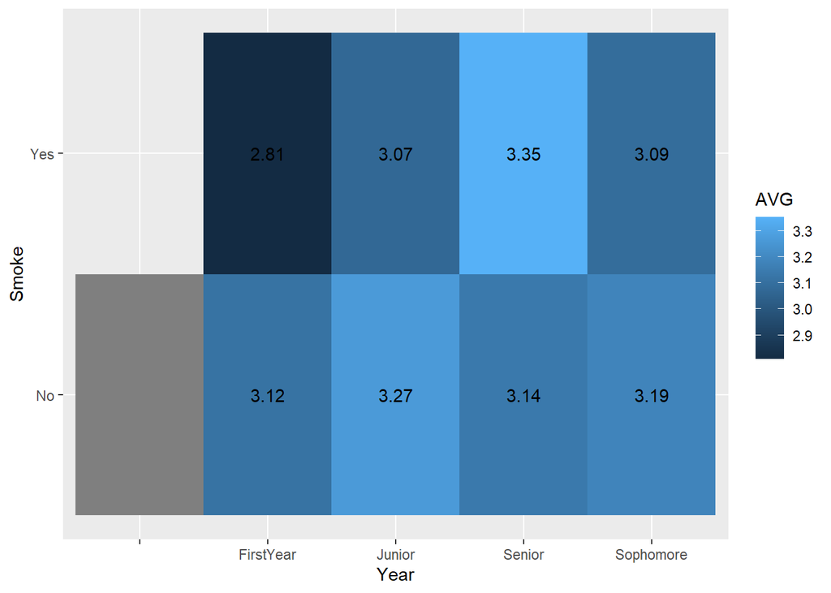

```r
df |>
  group_by(Year, Smoke) |>
  summarise(AVG = mean(GPA, na.rm = TRUE)) |>
  ggplot(aes(x = Year, y = Smoke, fill = AVG)) +
  geom_tile() +
  geom_text(aes(label = round(AVG,2)))
```

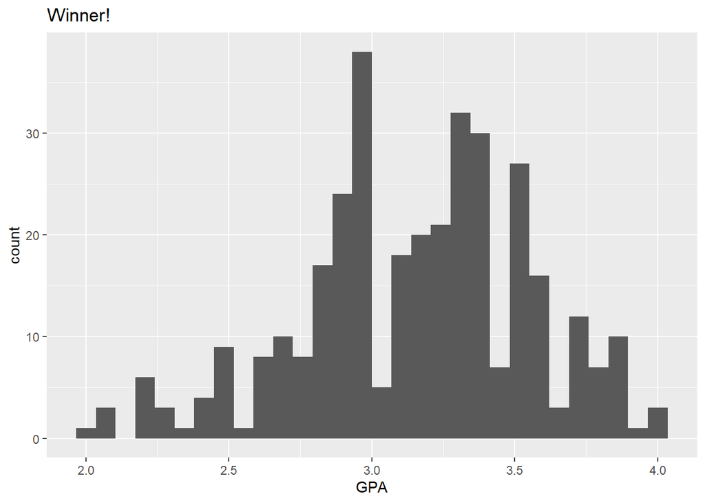

```r
ggplot(df, aes(x = GPA))+
  geom_histogram() +
  labs(title = "Winner!")
```

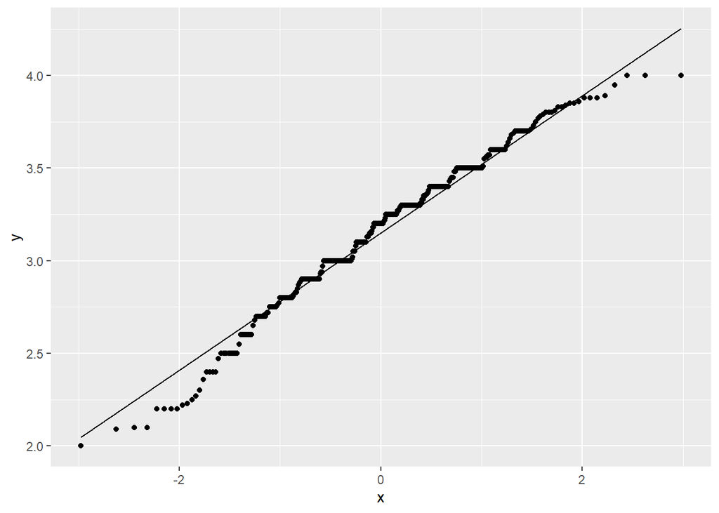

```r
ggplot(df)+
  geom_qq(aes(sample = GPA)) +
  geom_qq_line(aes(sample = GPA))
```

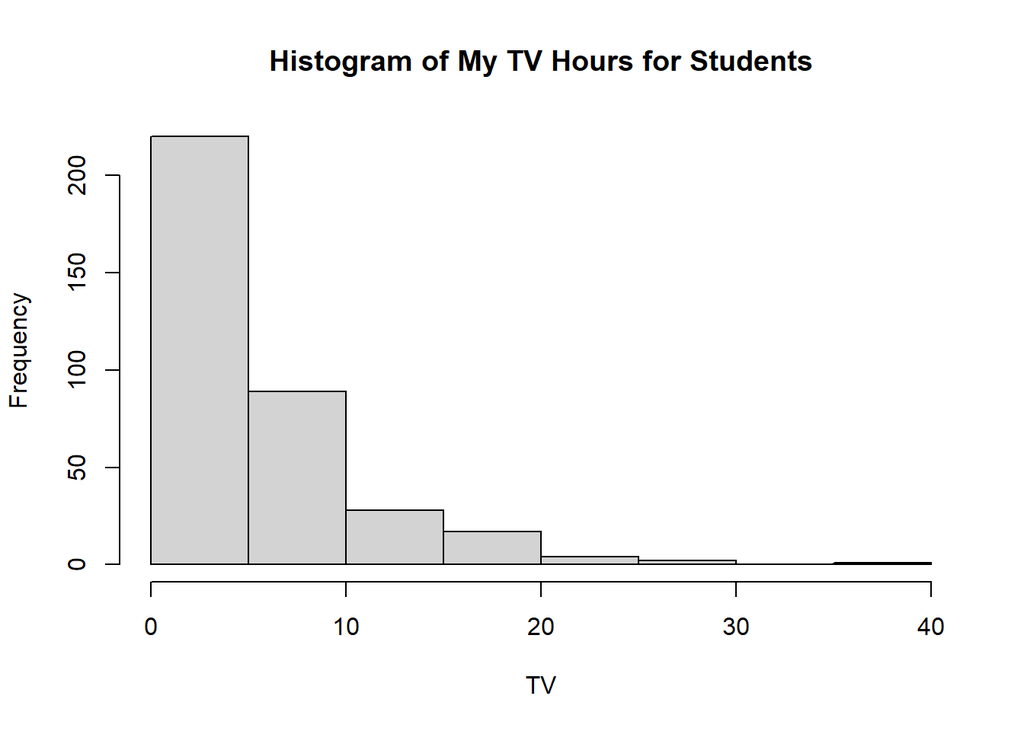

```r
#, include = FALSE}
hist(df$TV, xlab = "TV",main = "Histogram of My TV Hours for Students")
```

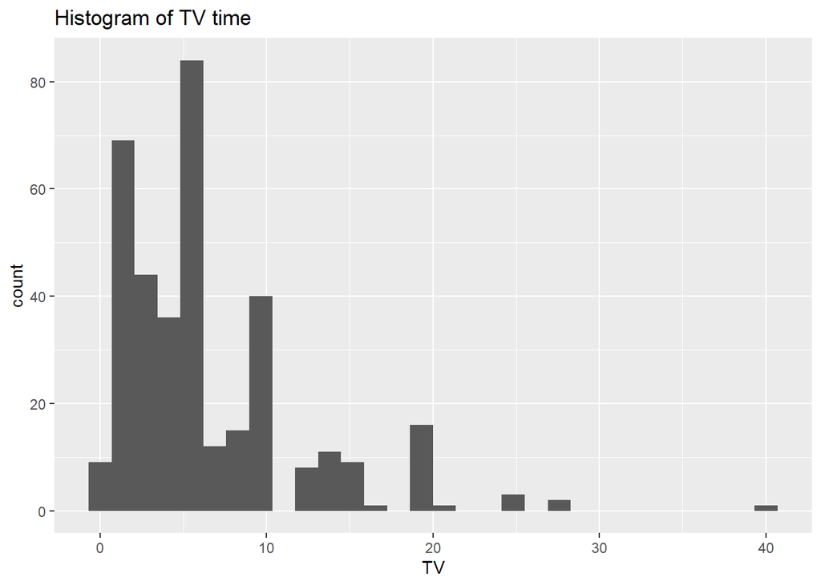

```r
ggplot(df, aes(x = TV))+
  geom_histogram() +
  labs(title = "Histogram of TV time")
```

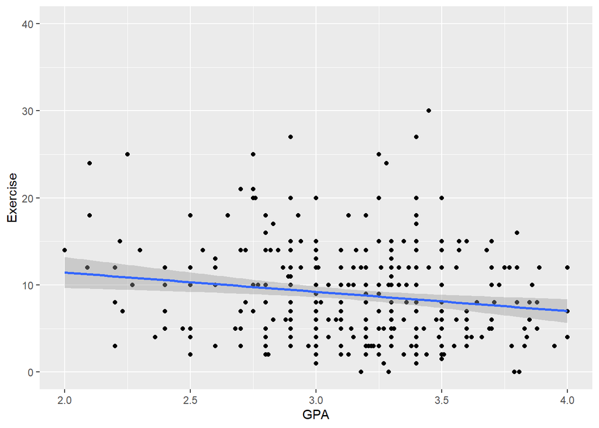

```r
ggplot(df, aes(x = GPA, y = Exercise))+
  geom_point()+
  geom_smooth(method = lm)
```

## Adding More to Your Graphics

Good graphs should have

1. Descriptive title
2. Appropriate Labels
3. Colors that are consistent and make sense
4. Allow the reader to glean the data quickly

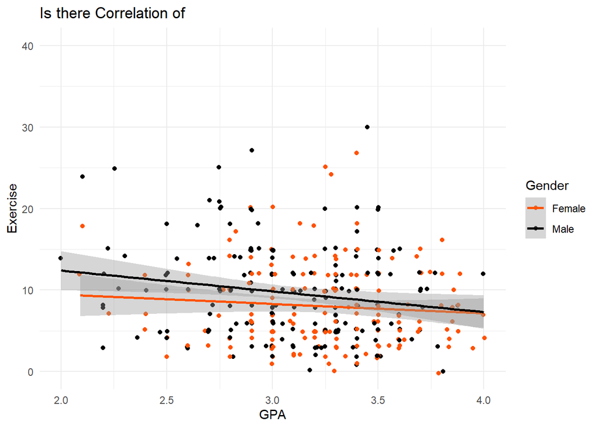

[interactive chart not shown]

```r
ggplot(df, aes(x = GPA, y = Exercise,color = Gender))+
  geom_jitter()+
  geom_smooth(method = lm) +
  labs(title = "Is there Correlation of ", alt = "Graph revealing the correlation of female and males with gpa and exercise")+
  scale_color_manual(labels = c("Female","Male"), values = c('#FF5200','black' ))+
  theme_minimal()
```